*This notebook contains material from nbpages by Jeffrey Kantor (jeff at nd.edu). The text is released under the [CC-BY-NC-ND-4.0 license](https://creativecommons.org/licenses/by-nc-nd/4.0/legalcode). The code is released under the [MIT license](https://opensource.org/licenses/MIT).*

# 2.1 Tagging

## 2.1.1 Tagging cells

differential-equations SIR-model compartmental-model

### 2.1.1.1 SIR model without vital dynamics

The [Susceptible-Infectious-Recovered (SIR) model](https://en.wikipedia.org/wiki/Compartmental_models_in_epidemiology) is an example of a compartmental model that is widely used to forecast the progress of disease epidemics.

\begin{align} \frac{dS}{dt} & = -\frac{\beta I S}{N} \\ \frac{dI}{dt} & = \frac{\beta I S}{N} - \gamma I \\ \frac{dR}{dt} & = \gamma I \end{align}

Where the **basic reproduction number** $R_0 = \frac{\beta}{\gamma}$

scipy.integrate.solve_ivp differential-equations

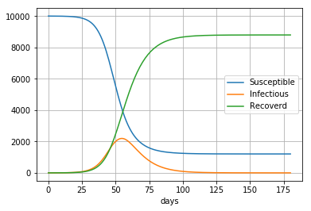

```python
%matplotlib inline

import numpy as np
import matplotlib.pyplot as plt
from scipy.integrate import solve_ivp

N = 10000.0
R0 = 2.4
gamma = 1/8.0
beta = gamma*R0

def deriv(t, y):
    S, I, R = y
    dSdt = -beta*I*S/N
    dIdt = beta*I*S/N - gamma*I
    dRdt = gamma*I
    return [dSdt, dIdt, dRdt]

t = np.linspace(0, 180, 181)
y0 = [N - 1.0, 1.0, 0.0]
soln = solve_ivp(deriv, [t[0], t[-1]], y0, t_eval=t)

plt.plot(soln.t, soln.y[0], label='Susceptible')
plt.plot(soln.t, soln.y[1], label='Infectious')
plt.plot(soln.t, soln.y[2], label='Recoverd')
plt.legend()
plt.xlabel('days')
plt.grid(True)
```

# 2.1 Special formatting for special tags

home-activity differential-equations

**Home Activity**:

### 2.1.1 SIR model without vital dynamics

The [Susceptible-Infectious-Recovered (SIR) model](https://en.wikipedia.org/wiki/Compartmental_models_in_epidemiology) is an example of a compartmental model that is widely used to forecast the progress of disease epidemics.

\begin{align} \frac{dS}{dt} & = -\frac{\beta I S}{N} \\ \frac{dI}{dt} & = \frac{\beta I S}{N} - \gamma I \\ \frac{dR}{dt} & = \gamma I \end{align}

Where the **basic reproduction number** $R_0 = \frac{\beta}{\gamma}$

This cell has been tagged with "home-activity".

class-activity

**Class Activity**:

This cell has been tagged with "class-activity".

important-note

**Important Note**:

This cell has been tagged with "important-note".

## 2.1.1 Tagging solutions in code cells

exercise

### 2.1.1.1 Exercise 1.

In the following cell write a function that returns the square of a number.

exercise

```python
# write a function that returns the square of a number

### BEGIN SOLUTION
def sqr(x):
    return x**2
### END SOLUTION

assert sqr(2) == 4
assert sqr(-1) == 1

### BEGIN HIDDEN TESTS
assert sqr(3) == 9
assert abs(sqr(3.3) - 10.89) < 0.001
### END HIDDEN TESTS
```